# Raportu snu - 2024

Bartosz Karpowicz

2025-01-27

Sylwester już dawno za mną i nie ukrywam, że z ciekawością oczekuję na to, co przyniesie mi rok 2025. Mimo wszystko warto podsumować poprzednie 12 miesięcy i odpowiedzieć na ważne pytanie: *Jak dobrze mi się spało w 2024 roku?*

### Metodologia

Przyzwyczaiłem sie do noszenia swojego smartwach’a, a co za tym idzie, już od dłuższego czasu staram się mieć go na sobie na czas snu. Niespodziewanie z mojego nawyku powstał obszerny zbiór danych, który zaciekawił mnie na tyle, że postanowiłem przyjrzeć mu się bliżej i przeanalizować zgromadzone dane. Nazwa zegarka to **HUAWEI WATCH GT 2e-97C**. Dane pozyskane zostały z aplikacji Huawei Zdrowie.

### Czyszczenie i transformacja danych

Na początek wczytamy paczki potrzebne do wykonywania operacji na danych oraz wizualizacji.

```r
#Do zainstalowania paczek służy funkcja install.packages("nazwa_paczki")
library(dplyr)
library(lubridate)
library(ggplot2)
```

Teraz wczytamy dane z pliku csv, który dostępny jest do pobrania w odpowiednim [repozytorium](https://github.com/bkarpowicz4/sen_raport_2024) na moim GitHubie. Następnie niektóre zmienne zostaną przekształcone na kategoryczne.

```r
dane <- read.csv("C:/Users/Bartosz/OneDrive - SGH/Pulpit/R projekty/sen_raport_2024/sen 2024 - kompletne dane.csv")

#Formatowanie zmiennych
dane$Dzień.tygodnia <- as.factor(dane$Dzień.tygodnia)
dane$Dzień.miesiąca <- as.factor(dane$Dzień.miesiąca)
dane$Miesiąc <- as.factor(dane$Miesiąc)
dane$Tydzień <- as.factor(dane$Tydzień)
dane$czy.zasnąłem.po.północy. <- as.factor(dane$czy.zasnąłem.po.północy.)
dane$Data <- ymd(dane$Data)

#Tworzenie zmiennej kategorycznej opisującej porę wstania oraz zaśnięcia
dane <- dane %>%
  mutate(sleepcat=as.factor(Godzina.zaśnięcia),
         awakecat=as.factor(Godzina.wybudzenia))
levels(dane$awakecat) <- c("3.00-4.00","4.00-5.00","5.00-6.00","6.00-7.00","7.00-8.00","8.00-9.00","9.00-10.00","10.00-11.00","11.00-12.00")
levels(dane$sleepcat) <- c("0.00-1.00","1.00-2.00","2.00-3.00","3.00-4.00","4.00-5.00","6.00-7.00","20.00-21.00","21.00-22.00","22.00-23.00","23.00-0.00")
```

### Wyniki i wizualizacje

Nie zebrano pomiarów dla 24 dni: oznacza to, że około **93%** wszystkich nocy w 2024 miałem zegarek na ręce podczas snu. Przyjrzyjmy się teraz podstawowym statystykom opisowym wybranych zmiennych:

```
## # A tibble: 12 × 5
##    Miesiąc avg_sleep_time avg_time_in_bed avg_wakeup avg_diff
##    <fct>            <dbl>           <dbl>      <dbl>    <dbl>
##  1 1                 440.            465.       3.19     24.3
##  2 2                 468.            502.       4.08     37.3
##  3 3                 412.            430.       3.14     19.6
##  4 4                 428.            449.       3.63     23.6
##  5 5                 399.            411.       2.94     14.3
##  6 6                 386.            400.       3.14     14.4
##  7 7                 425.            478.       4.89     54.4
##  8 8                 447.            467.       3.16     22.1
##  9 9                 414.            465.       4.90     51.5
## 10 10                375.            436.       5.94     67.8
## 11 11                426.            462.       6.3      48.6
## 12 12                459.            475.       5.17     35.0
```

Średnia długość snu w 2024 była równa **422** minut, co daje około **7.03** godziny. Najkrótszy sen trwał **01:48:00** i miał on miejsce 2024-06-03, a najdłuższy **11:19:00** i wystąpił on w dniu 2024-12-24 (daty zapisane w systemie amerykańskim).

Takie suche liczby na pierwszy rzut oka niewiele nam mówią. Zatem lepiej zaprezentować to, co mają do przekazania za pomocą wykresów. Spójrzmy zatem na wykres, który przedstawia jak często chodziłem spać w danym przedziale czasu:

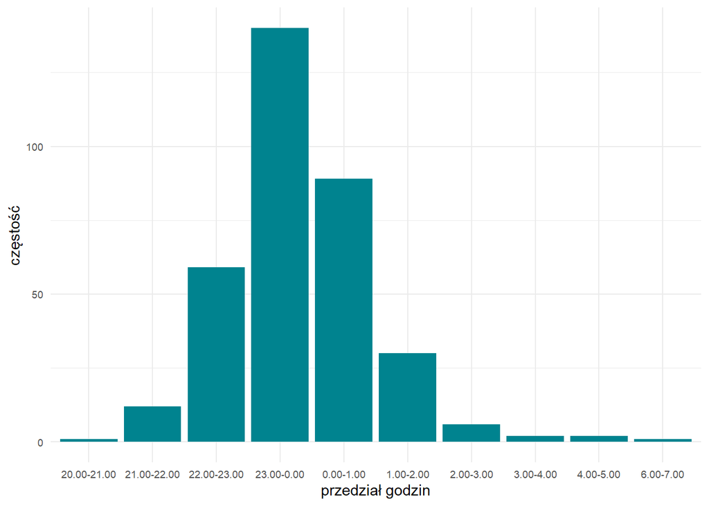

Najczęściej zasypiałem między godziną **23.00 a 0.00**. A jak prezentuje się taki sam wykres, lecz odnoszący się do wstawania w danym przedziale czasowym?

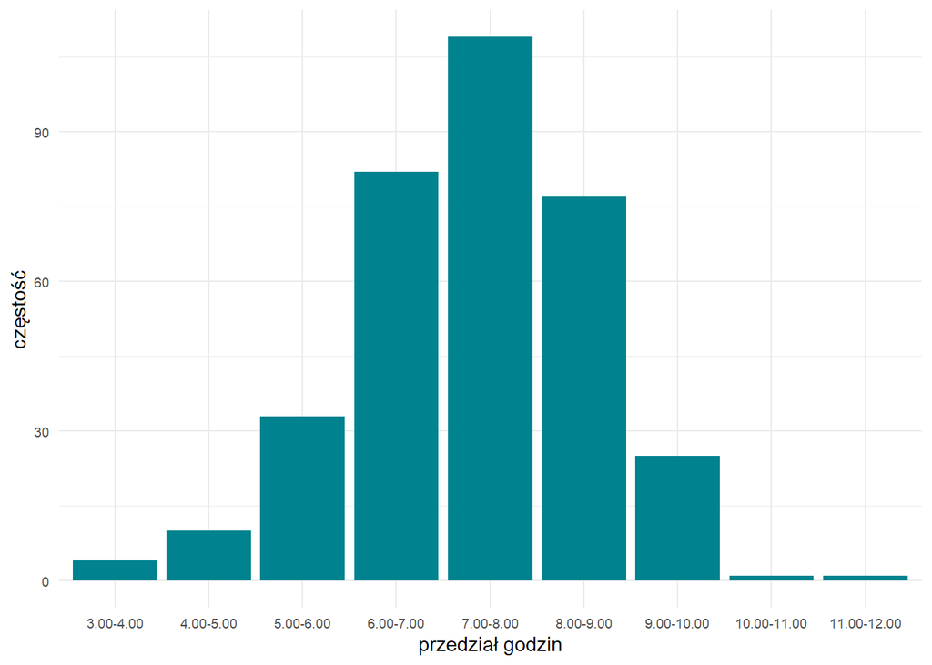

Najczęściej wstawałem między godziną **7.00 i 8.00**. Przez zdecydowaną większość roku wstawałem między godziną **6.00 i 9.00**.

Zobaczmy teraz ogólny wykres przespanych minut na przestrzeni roku oraz linię trendu.

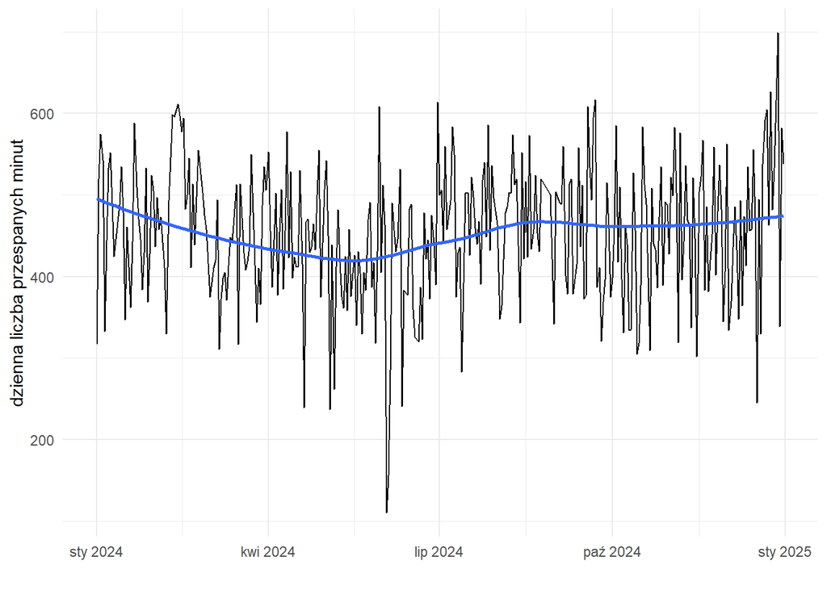

Porównajmy trendy przespanych minut dla każdego z miesięcy.

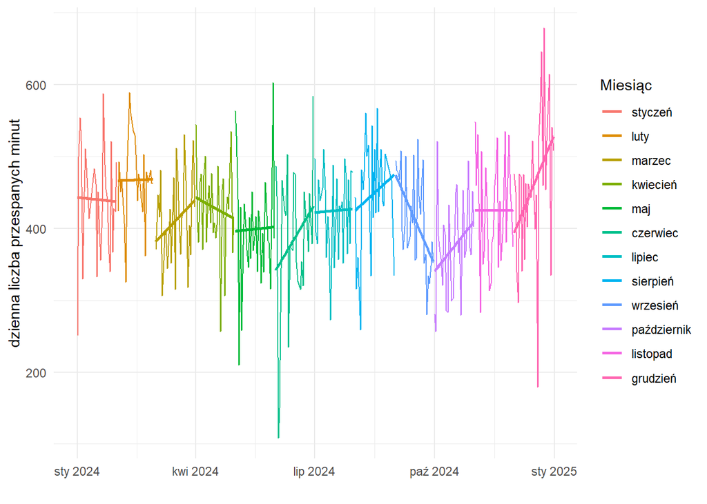

Njabradziej stabilnym miesiącem pod względem linii trendu był listopad. Największy spadek trendu na przestrzeni miesiąca wystąpił we wrześniu, a największy wzrost w grudniu.

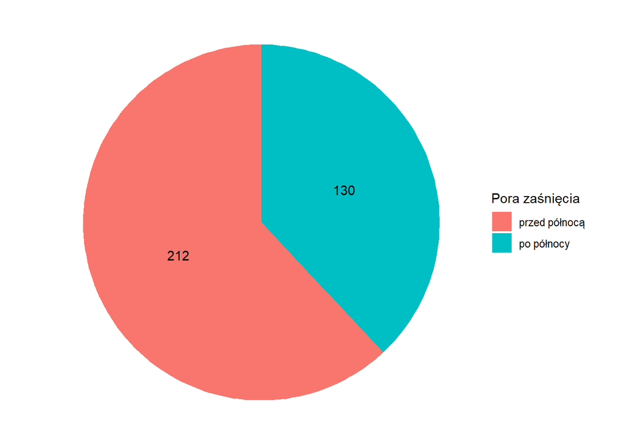

Powyższy wykres informuje, że w 2024 roku częściej zdarzało mi się zasypiać przed północą.

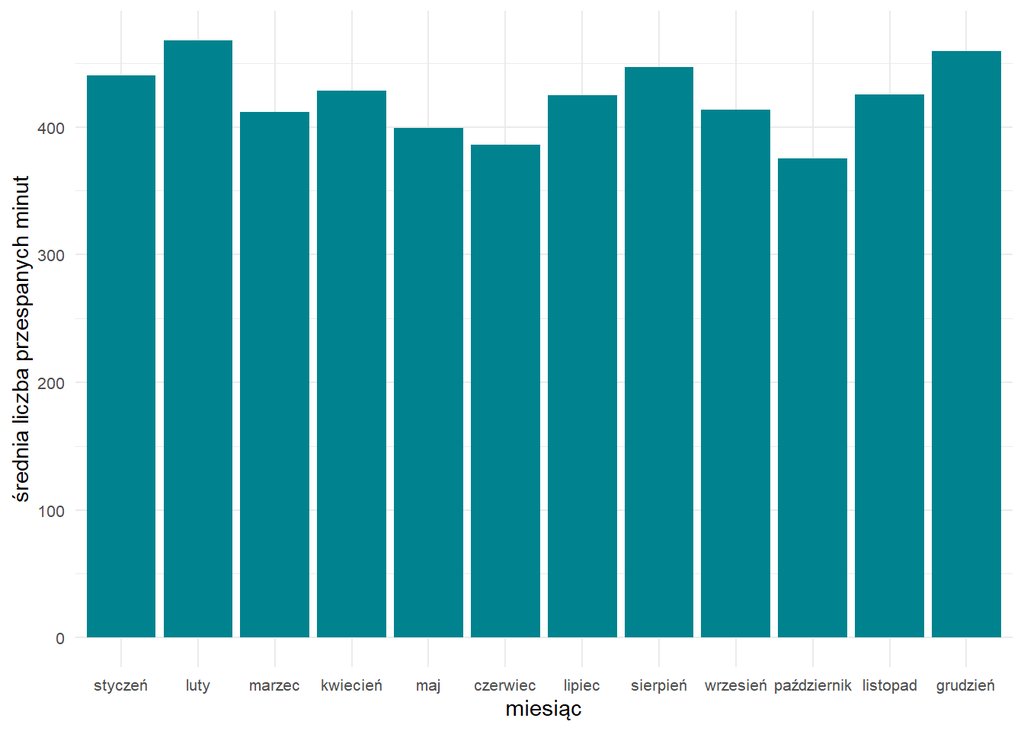

Najlepsze 3 miesiące pod względem średniej liczby przespanych minut to **luty, sierpień oraz grudzień**, natomiast najgorsze 3 miesiące to **maj, czerwiec i październik**.

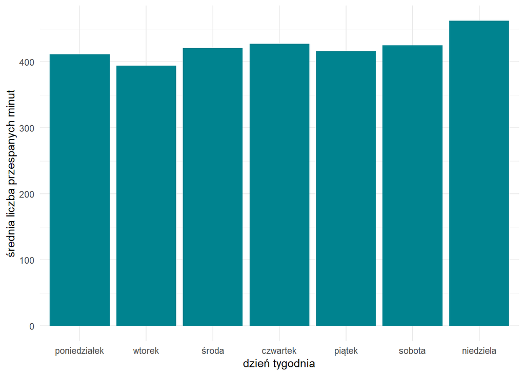

Z powyższego wykresu wynika, że największa średnia przespanych minut w 2024 roku przypadła na niedzielę. Najlepszym wytłumaczeniem takiego stanu rzeczy jest prawdpopodobnie to, że w ten dzień nadrabiałem niedobór snu “wypracowany” w poprzednich dniach tygodnia (albo był to jeden ze sposobów na nudę).

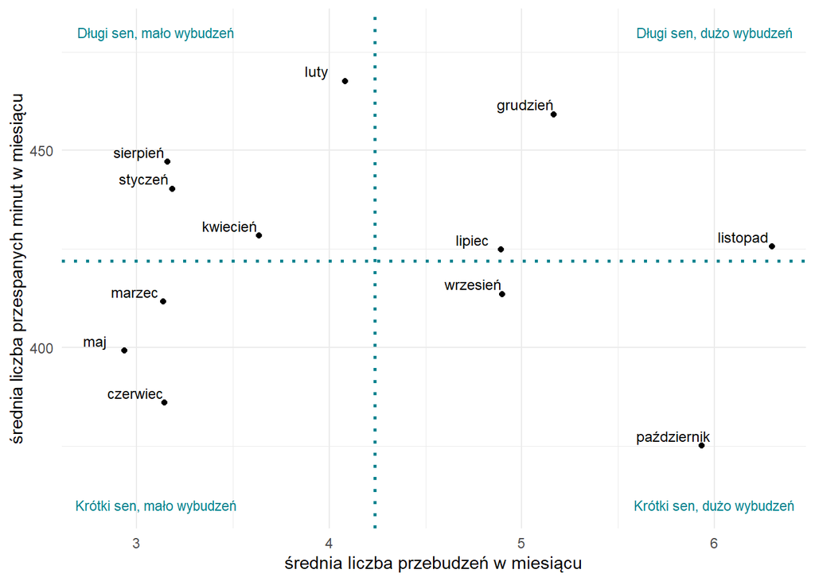

*Po więcej ciekawych projektów, zajrzyj na https://github.com/bkarpowicz4.*